# p8105_hw5_sz2800

Stephanie Zhen

11/11/2019

```r
library(tidyverse)
```

### Pre-Question 1:

```r
set.seed(10)

iris_with_missing = iris %>%
  janitor::clean_names() %>%
  map_df(~replace(.x, sample(1:150, 20), NA)) %>%
  mutate(species = as.character(species))
```

## QUestion 1:

```r
iris_missing_na = function(x) {
  if (is.numeric(x)) {
    x = replace_na(x, mean(x, na.rm = TRUE))}
  else if (!is.numeric(x)){
    x = replace_na(x, "virginica")
  }
}

output_iris = map_df(iris_with_missing, iris_missing_na)
```

Imputation of missing numeric values:Missing numeric values are replaced with the mean of that variables. Missing character values for the variable “species” are replaced with “virginica.”

### Question 2:

```r
all_files = list.files(path = "./data") %>%
  tibble::enframe(name = NULL) %>%
  mutate(
    read_all_data = map(value, ~read_csv(str_c("./data/", .x)))
    ) %>%
  unnest(read_all_data) %>%
  separate(value, into = c("txt_group", "subject_id")) %>%
  mutate(subject_id = str_c(txt_group, subject_id))
  files_tidy = pivot_longer(
    all_files,
    week_1:week_8,
    names_to = "week",
    names_prefix = "week_",
    values_to = "sub_obs") %>%
    mutate(week = as.numeric(week))

knitr::kable(files_tidy,
             format = "html",
             digits = 3,
             caption = "Observation values with respect to Week")
```

Observation values with respect to Week

| txt_group | subject_id | week | sub_obs |
| --- | --- | --- | --- |
| con | con01 | 1 | 0.20 |
| con | con01 | 2 | -1.31 |
| con | con01 | 3 | 0.66 |
| con | con01 | 4 | 1.96 |
| con | con01 | 5 | 0.23 |
| con | con01 | 6 | 1.09 |
| con | con01 | 7 | 0.05 |
| con | con01 | 8 | 1.94 |
| con | con02 | 1 | 1.13 |
| con | con02 | 2 | -0.88 |
| con | con02 | 3 | 1.07 |
| con | con02 | 4 | 0.17 |
| con | con02 | 5 | -0.83 |
| con | con02 | 6 | -0.31 |
| con | con02 | 7 | 1.58 |
| con | con02 | 8 | 0.44 |
| con | con03 | 1 | 1.77 |
| con | con03 | 2 | 3.11 |
| con | con03 | 3 | 2.22 |
| con | con03 | 4 | 3.26 |
| con | con03 | 5 | 3.31 |
| con | con03 | 6 | 0.89 |
| con | con03 | 7 | 1.88 |
| con | con03 | 8 | 1.01 |
| con | con04 | 1 | 1.04 |
| con | con04 | 2 | 3.66 |
| con | con04 | 3 | 1.22 |
| con | con04 | 4 | 2.33 |
| con | con04 | 5 | 1.47 |
| con | con04 | 6 | 2.70 |

[output cut: 130 more lines]

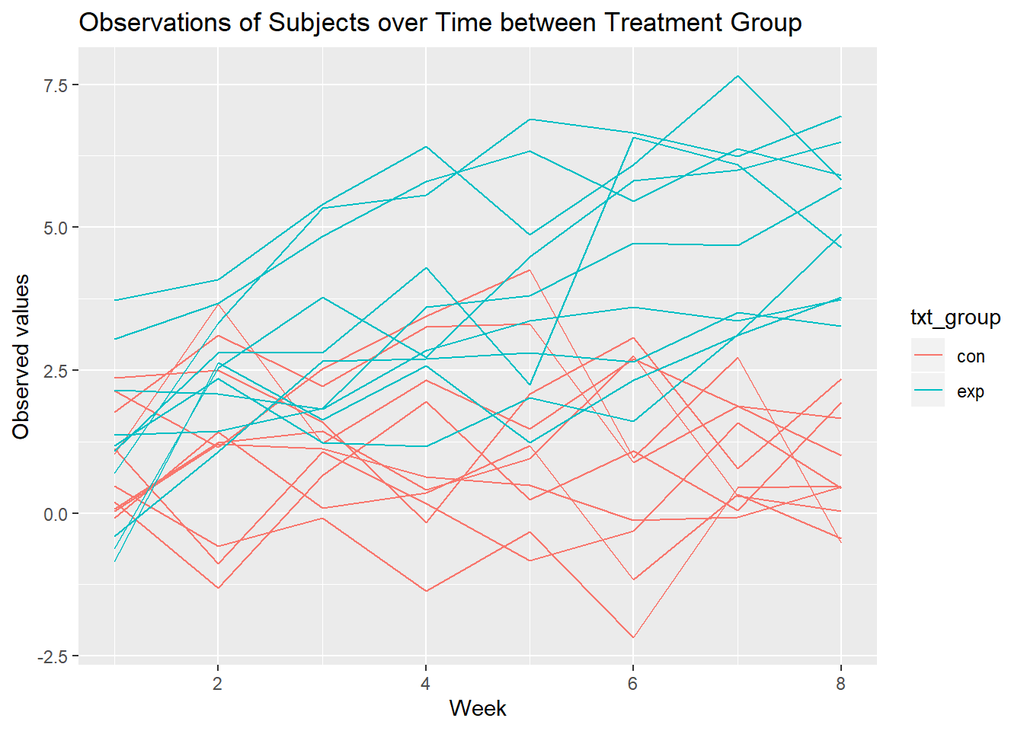

```r
files_tidy_plot = ggplot(
  files_tidy,
  aes(x = week,
      y = sub_obs,
      color = txt_group,
      group = subject_id)) +
  geom_path() +
  labs(x = "Week", y = "Observed values", title = "Observations of Subjects over Time between Treatment Group", fill = "Treatment arm")

files_tidy_plot
```

The experimental arm has higher observed values than when compared to the control arm. SUbjects in the experimental arm also have a small increased in observed values over time, whereas there is no difference in observed value for the control group over time.

### Question 3: Generating random samples

```r
set.seed(1)
prob3_sim_reg = function(n = 30, beta0 = 2, var = 50, beta1) {

  sim_data = tibble(
    x = rnorm(n, mean = 0, sd = 1),
    y = beta0 + beta1 * x + rnorm(n, 0, var)
  )

  ls_sim = lm(y ~ x, data = sim_data) %>%
    broom::tidy() %>%
    filter(term == "x")

  tibble(
    beta1_hat = pull(ls_sim, estimate),
    p_value = pull(ls_sim, p.value)
  )
}
```

Iterating over beta1

```r
output_sim_reg =
  tibble(beta1 = c(1, 2, 3, 4, 5, 6)) %>%
  mutate(
    output_lists = map(.x = beta1, ~rerun(10000, prob3_sim_reg(beta1 = .x))),
    estimate_dfs = map(output_lists, bind_rows)) %>%
  select(-output_lists) %>%
  unnest(estimate_dfs)

output_sim_reg
```

```
## # A tibble: 60,000 x 3
##    beta1 beta1_hat p_value
##    <dbl>     <dbl>   <dbl>
##  1     1      3.09   0.706
##  2     1      1.05   0.905
##  3     1    -14.2    0.182
##  4     1     -2.21   0.804
##  5     1     -2.64   0.802
##  6     1     13.1    0.207
##  7     1     -7.37   0.382
##  8     1      8.72   0.308
##  9     1      6.70   0.301
## 10     1     17.7    0.110
## # ... with 59,990 more rows
```

Proportion times the null was rejected

```r
ls_reject_pre = output_sim_reg %>%
  group_by(beta1) %>%
  summarize(n = n(),
            reject = sum(p_value <= 0.05),
            non_reject = sum(p_value > 0.05),
            prop_reject = (reject/n))

ls_reject_pre
```

```
## # A tibble: 6 x 5
##   beta1     n reject non_reject prop_reject
##   <dbl> <int>  <int>      <int>       <dbl>
## 1     1 10000    510       9490      0.051
## 2     2 10000    502       9498      0.0502
## 3     3 10000    633       9367      0.0633
## 4     4 10000    767       9233      0.0767
## 5     5 10000    849       9151      0.0849
## 6     6 10000    974       9026      0.0974
```

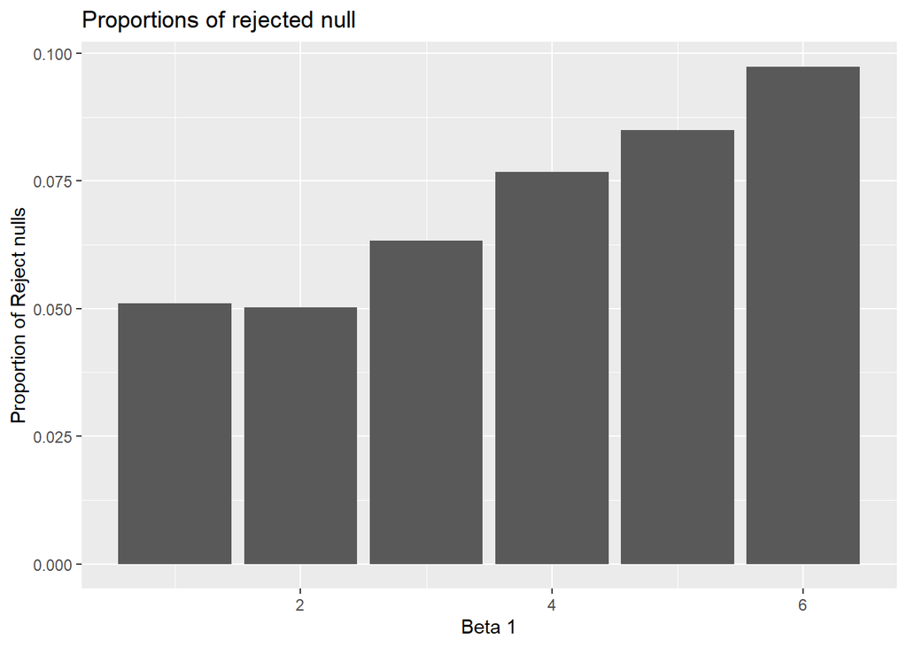

```r
ls_reject_hist = ls_reject_pre %>%
  ggplot(aes(x = beta1, y = prop_reject)) +
  geom_histogram(stat = "identity") +
  labs(x = "Beta 1", y = "Proportion of Reject nulls", title = "Proportions of rejected null")
ls_reject_hist
```

THe effect size is the difference between the two means, estimated and null mean. When the null hypothesis is rejected, the differences between means are large, which results in a larger effect size. Power is the probability of rejecting the null correctly (null is not true and reject null). Therefore, the larger the effect size, the higher the statistical power.

Average beta1 hat value vs average beta1 hat value of rejected null.

```r
ls_beta_avg_pre = output_sim_reg %>%
  group_by(beta1) %>%
  summarize(avg_beta_hat = mean(beta1_hat))

ls_beta_avg_pre
```

```
## # A tibble: 6 x 2
##   beta1 avg_beta_hat
##   <dbl>        <dbl>
## 1     1        0.820
## 2     2        1.97
## 3     3        3.03
## 4     4        3.94
## 5     5        5.08
## 6     6        6.00
```

```r
ls_bavg_rej_pre = output_sim_reg %>%
  filter(p_value <= 0.05) %>%
  group_by(beta1) %>%
  summarize(avg_betah_rej = mean(beta1_hat))

ls_bavg_rej_pre
```

```
## # A tibble: 6 x 2
##   beta1 avg_betah_rej
##   <dbl>         <dbl>
## 1     1          4.80
## 2     2          9.45
## 3     3         14.1
## 4     4         15.8
## 5     5         18.8
## 6     6         20.1
```

```r
full = ls_beta_avg_pre %>%
  inner_join(ls_bavg_rej_pre, by = "beta1")

full
```

```
## # A tibble: 6 x 3
##   beta1 avg_beta_hat avg_betah_rej
##   <dbl>        <dbl>         <dbl>
## 1     1        0.820          4.80
## 2     2        1.97           9.45
## 3     3        3.03          14.1
## 4     4        3.94          15.8
## 5     5        5.08          18.8
## 6     6        6.00          20.1
```

```r
longer = full %>%
  pivot_longer(
    avg_beta_hat:avg_betah_rej,
    names_to = "beta1_hat",
    values_to = "beta1_hat_value"
  )

knitr::kable(longer,
             format = "html",
             digits = 3,
             caption = "Avg Beta Hat vs Avg Beta hat reject values")
```

Avg Beta Hat vs Avg Beta hat reject values

| beta1 | beta1_hat | beta1_hat_value |
| --- | --- | --- |
| 1 | avg_beta_hat | 0.820 |
| 1 | avg_betah_rej | 4.803 |
| 2 | avg_beta_hat | 1.966 |
| 2 | avg_betah_rej | 9.448 |
| 3 | avg_beta_hat | 3.034 |
| 3 | avg_betah_rej | 14.056 |
| 4 | avg_beta_hat | 3.945 |
| 4 | avg_betah_rej | 15.798 |
| 5 | avg_beta_hat | 5.082 |
| 5 | avg_betah_rej | 18.832 |
| 6 | avg_beta_hat | 5.996 |
| 6 | avg_betah_rej | 20.104 |

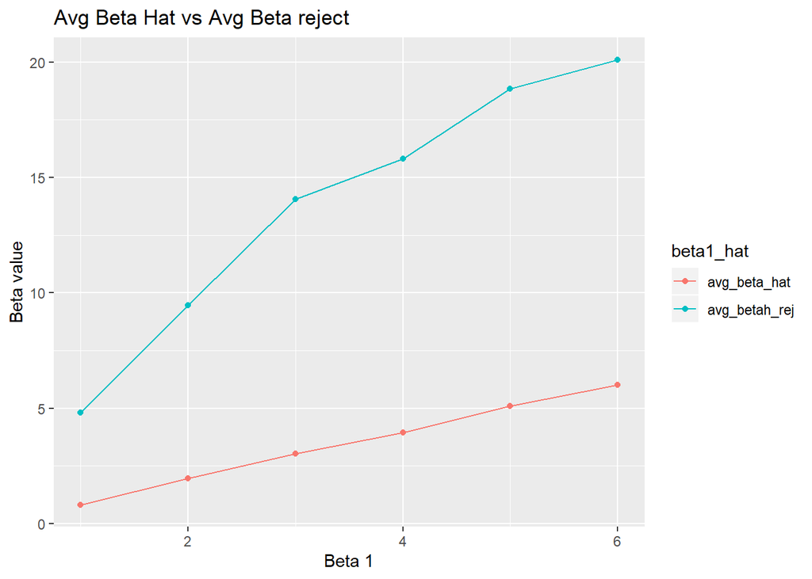

```r
ggplot(longer, aes(x = beta1, y = beta1_hat_value, color = beta1_hat, group = beta1_hat)) +
  geom_point() +
  geom_line() +
  labs(x = "Beta 1", y = "Beta value", title = "Avg Beta Hat vs Avg Beta reject")
```

Judging solely on the graph, the average beta1_hat values in which the null hypothesis is different from the true beta value. This most likely result from the large variance of 50. A large variance indicates a large standard error. Therefore, the obtain a large test statistics (t = estimated beta1_hat / SE), in order to reject the p-value the estimated beta1_hat_reject value must also be large.